# Practice with dplyr and ggplot2

Dr. Shoemaker

DATA 2401

## Fancy Histograms!

We’ll start by making some histograms.

```r
#install.packages("dslabs")
library(dslabs)

data(heights)
glimpse(heights)
```

```
## Rows: 1,050
## Columns: 2
## $ sex    <fct> Male, Male, Male, Male, Male, Female, Female, Female, Female, M…
## $ height <dbl> 75, 70, 68, 74, 61, 65, 66, 62, 66, 67, 72, 72, 69, 68, 69, 66,…
```

This data is the heights of humans, divided by their biological sex.

Use ggplot to make a histogram of all of the heights:

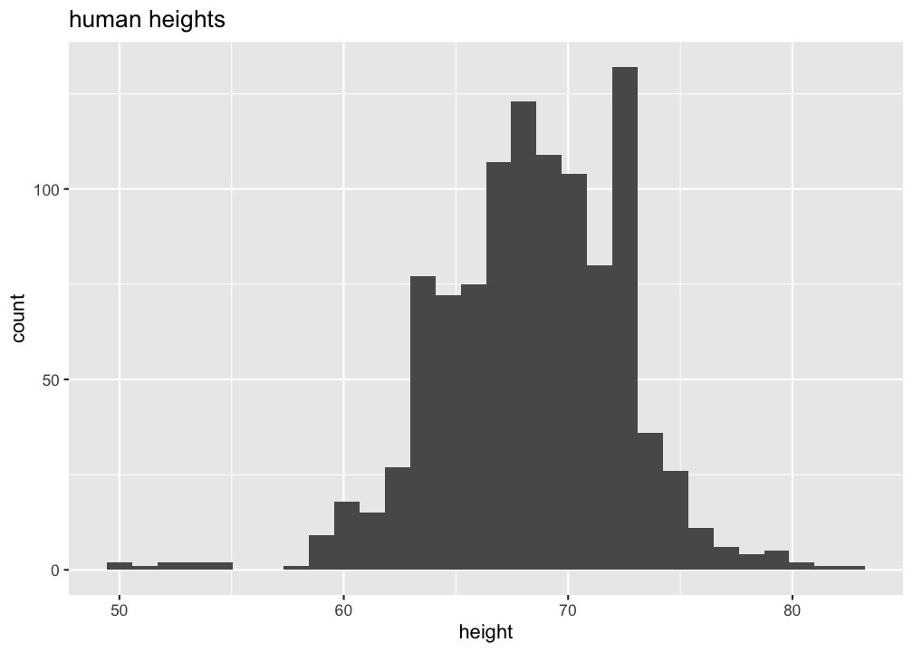

```r
heights |> ggplot(aes(x = height)) + geom_histogram() + labs(title = "human heights")
```

Change up the binwidth and see how the plots change. Try 1, 5, 10, and 20

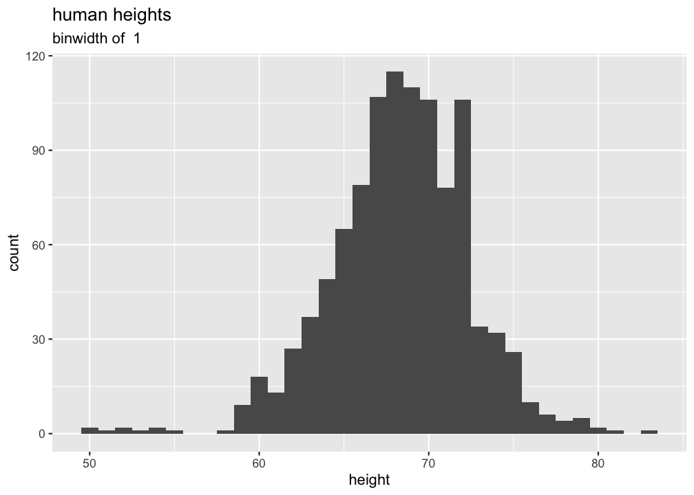

```r
bw <- 1
heights |> ggplot(aes(x = height)) + geom_histogram(binwidth = bw) + labs(title = "human heights", subtitle = paste("binwidth of ", bw))
```

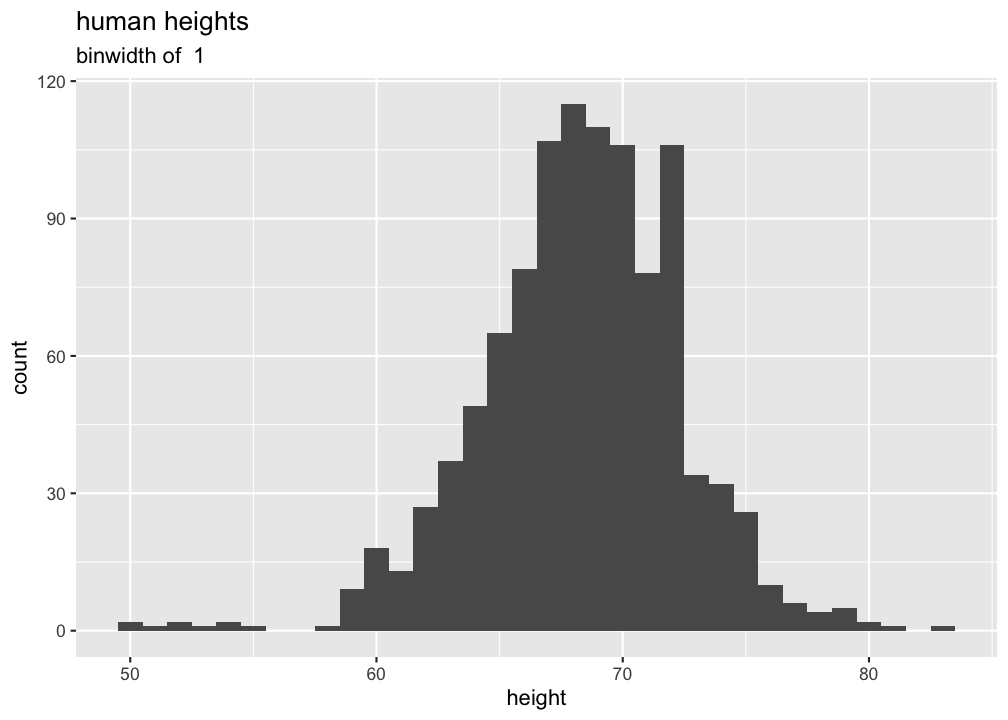

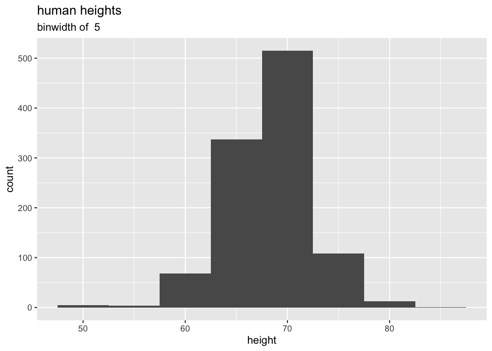

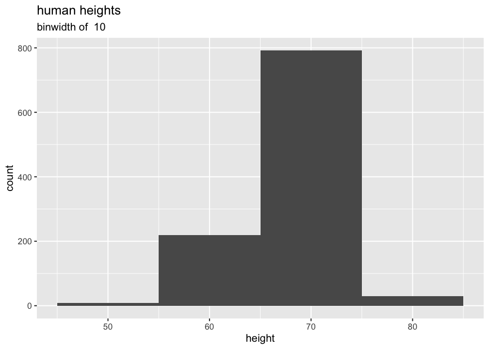

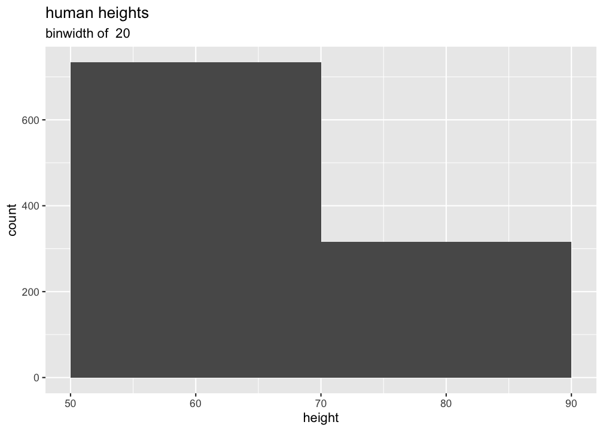

```r
# if you're interested in looping in R
for (bw in c(1, 5, 10, 20)) {
p <- heights |> ggplot(aes(x = height)) + geom_histogram(binwidth = bw) + labs(title = "human heights", subtitle = paste("binwidth of ", bw))
print(p)
}
```

Smooth this out to an empirical density with `geom_density()`

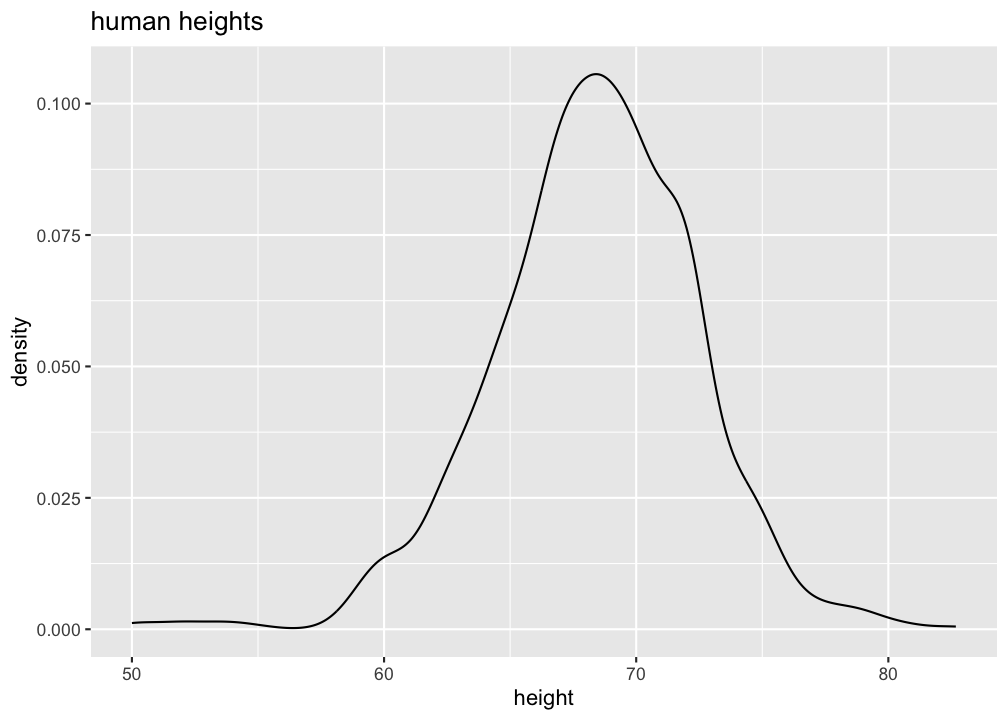

```r
heights |> ggplot(aes(x = height)) + geom_density() + labs(title = "human heights")
```

Use a new argument in the `aes()`, `group =` to split this density by sex

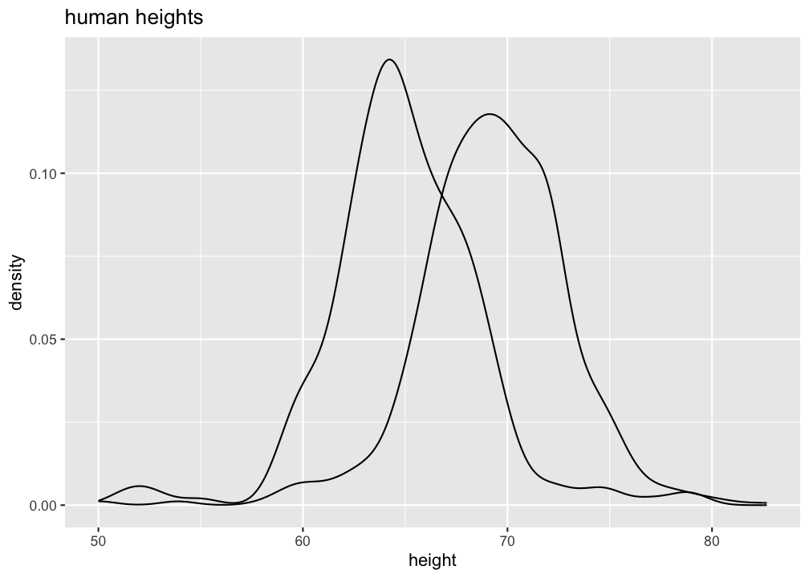

```r
heights |> ggplot(aes(x = height)) + geom_density(mapping = aes(group = sex)) + labs(title = "human heights")
```

OR we can do it with `color` or `fill.` If you say you want to color by sex, R knows that you want a different curve for each of them.

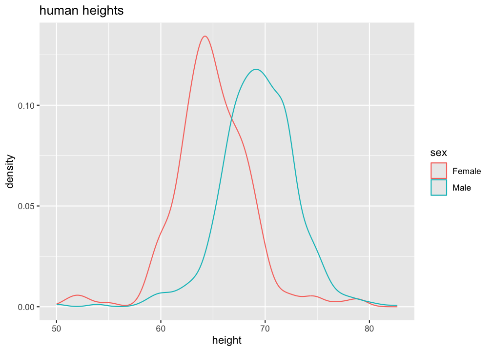

```r
heights |> ggplot(aes(x = height, color = sex)) + geom_density() + labs(title = "human heights")
```

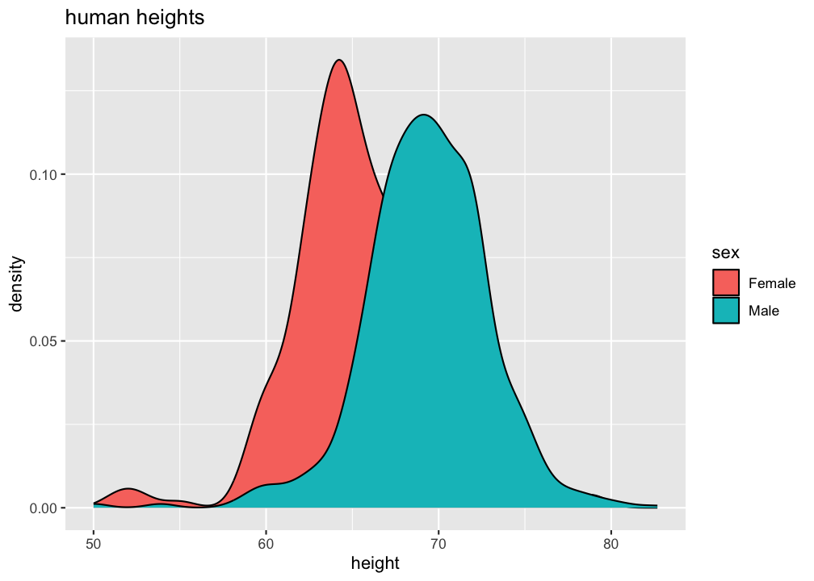

```r
heights |> ggplot(aes(x = height, fill = sex)) + geom_density() + labs(title = "human heights")
```

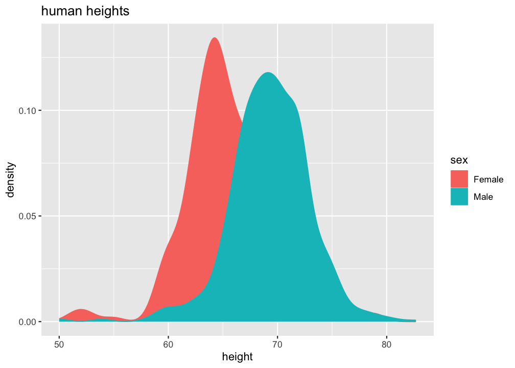

```r
heights |> ggplot(aes(x = height, color = sex, fill = sex)) + geom_density() + labs(title = "human heights")
```

```r
# honestly kinda my favorite cause it removes those outlines
```

If you’ve used fill, then there is now a slight issue that they are overlapped. We can fix this with alpha transparency!

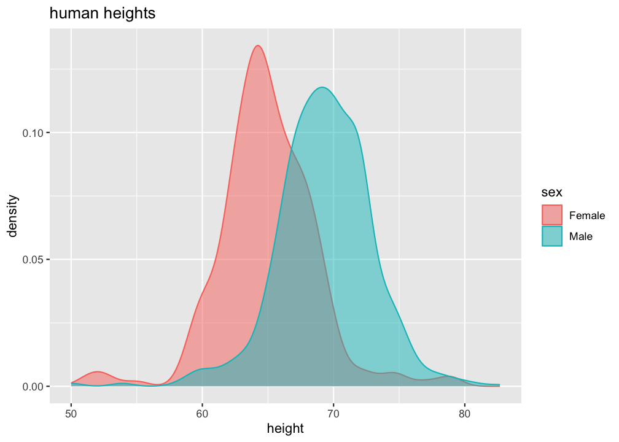

```r
heights |> ggplot(aes(x = height, color = sex, fill = sex)) + geom_density(alpha = 0.5) + labs(title = "human heights")
```

Let’s make some boxplots of the same information.

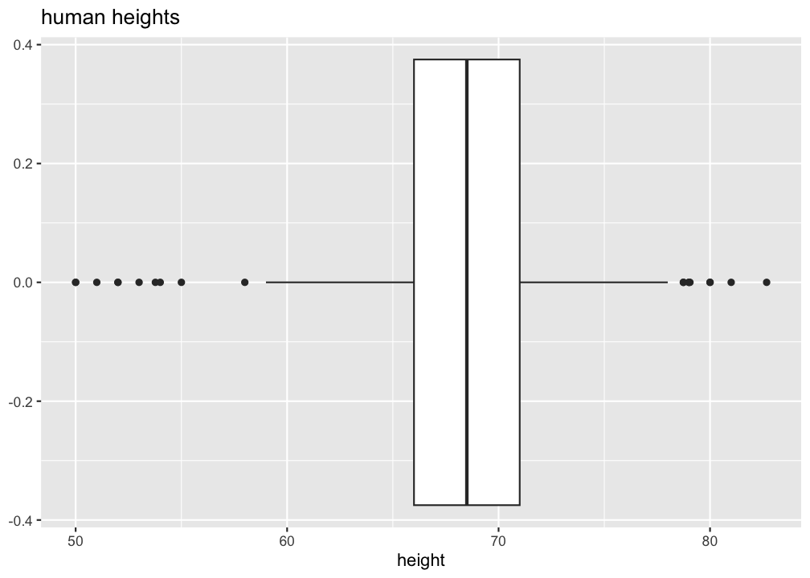

```r
## all heights (no sex split)
heights |> ggplot(aes(x = height)) + geom_boxplot() + labs(title = "human heights")
```

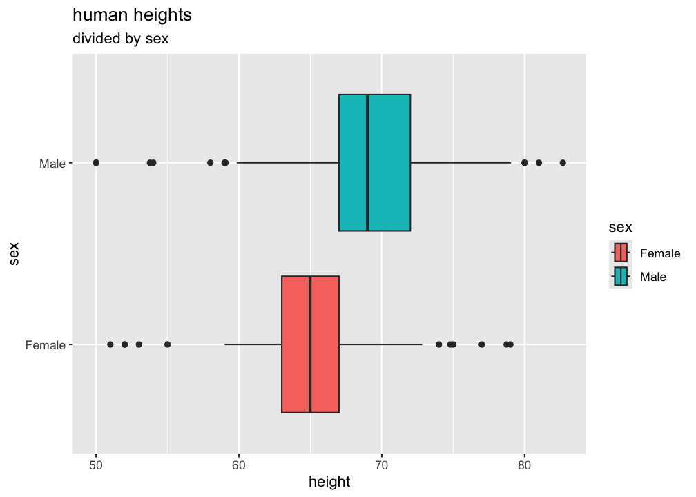

```r
## including the sec needs a y!
heights |> ggplot(aes(x = height, y = sex, fill = sex)) + geom_boxplot() + labs(title = "human heights", subtitle = "divided by sex")
```

## Quantatitive summaries:

Find the mean and median overall.

```r
heights |> summarise(mean_height = mean(height),
                     median_height = median(height))
```

```
##   mean_height median_height
## 1    68.32301          68.5
```

Find the mean and median for both groups.

```r
heights |> group_by(sex) |>
  summarise(mean_height = mean(height),
            median_height = median(height))
```

```
## # A tibble: 2 × 3
##   sex    mean_height median_height
##   <fct>        <dbl>         <dbl>
## 1 Female        64.9          65.0
## 2 Male          69.3          69
```

```r
## OR
# the "new way"

heights |> summarise(mean_height = mean(height),
                     median_height = median(height),
                    .by = sex)
```

```
##      sex mean_height median_height
## 1   Male    69.31475      69.00000
## 2 Female    64.93942      64.98031
```

How tall is the tallest woman? How short is the shortest man?

```r
heights |>
  group_by(sex) |>
  summarise(min_height_by_sex = min(height),
            max_height_by_sex = max(height))
```

```
## # A tibble: 2 × 3
##   sex    min_height_by_sex max_height_by_sex
##   <fct>              <dbl>             <dbl>
## 1 Female                51              79
## 2 Male                  50              82.7
```

```r
## or
heights |>
  filter(sex == "Male") |>
  slice_min(height)
```

```
##    sex height
## 1 Male     50
## 2 Male     50
```

```r
## or this nieche things
bind_rows(list(
      heights |> filter(sex == "Female") |> slice_max(height),
      heights |> filter(sex == "Male") |> slice_min(height)
      )
    )
```

```
##      sex height
## 1 Female     79
## 2   Male     50
## 3   Male     50
```

Use your summary table and pipe it to a ggplot to make a bar graph showing the mean of both groups.

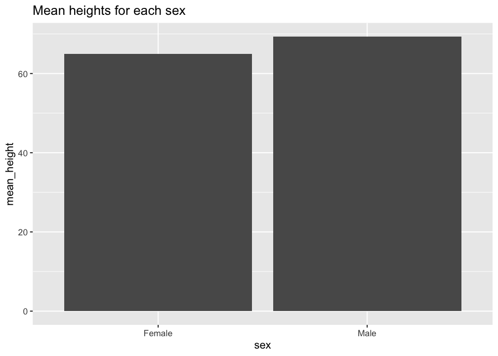

```r
heights |>
  group_by(sex) |>
  summarise(mean_height = mean(height),
            median_height = median(height))|>
  ggplot(aes(x = sex, y = mean_height)) +
  geom_col() +
  labs(title = "Mean heights for each sex")
```

## Layering plots!

Penguins!

```r
library(palmerpenguins)
glimpse(penguins)
```

```
## Rows: 344
## Columns: 8
## $ species           <fct> Adelie, Adelie, Adelie, Adelie, Adelie, Adelie, Adel…
## $ island            <fct> Torgersen, Torgersen, Torgersen, Torgersen, Torgerse…
## $ bill_length_mm    <dbl> 39.1, 39.5, 40.3, NA, 36.7, 39.3, 38.9, 39.2, 34.1, …
## $ bill_depth_mm     <dbl> 18.7, 17.4, 18.0, NA, 19.3, 20.6, 17.8, 19.6, 18.1, …
## $ flipper_length_mm <int> 181, 186, 195, NA, 193, 190, 181, 195, 193, 190, 186…
## $ body_mass_g       <int> 3750, 3800, 3250, NA, 3450, 3650, 3625, 4675, 3475, …
## $ sex               <fct> male, female, female, NA, female, male, female, male…
## $ year              <int> 2007, 2007, 2007, 2007, 2007, 2007, 2007, 2007, 2007…
```

We can use boxplots to visualize the distribution of weight (body_mass_g) within each species:

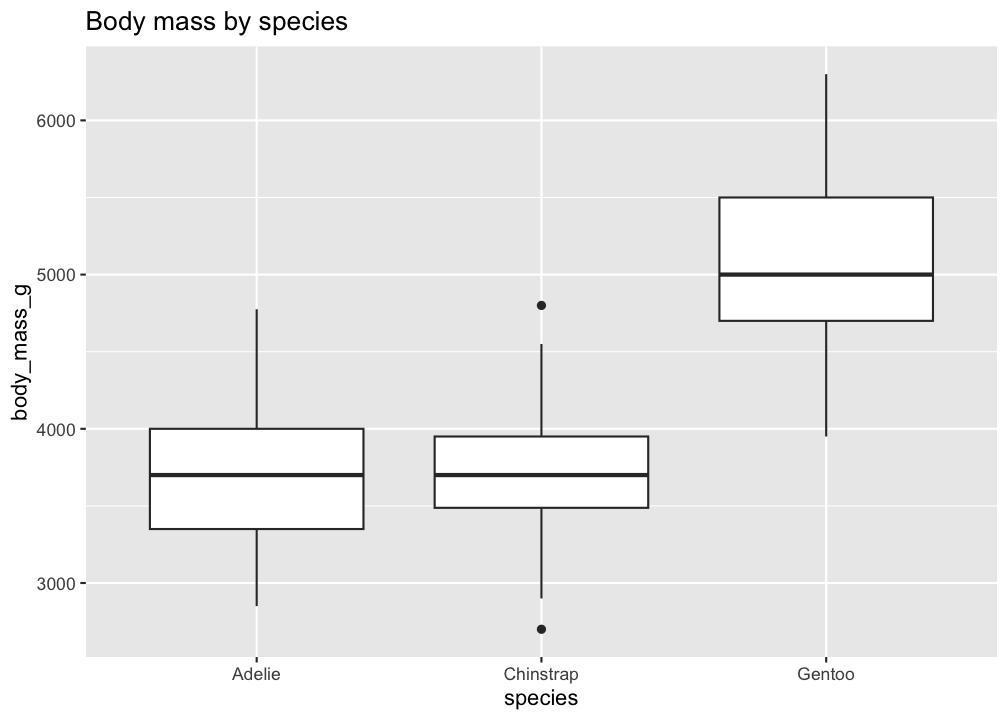

```r
penguins |>
  drop_na(body_mass_g) |>
  ggplot(aes(y = body_mass_g, x = species)) +
  geom_boxplot() +
  labs(title = "Body mass by species")
```

What if we also want the points? Layering!! Add a geom_point to your existing boxplot. geom_boxplot + geom_point!

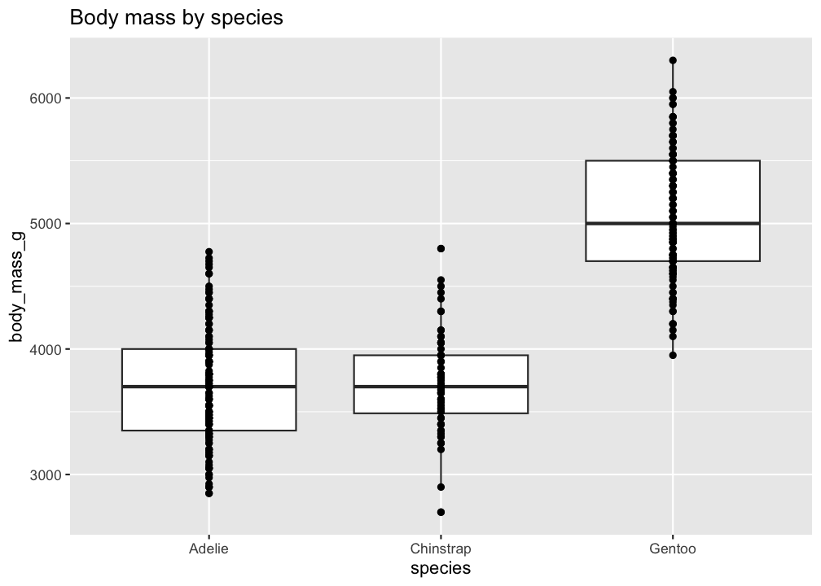

```r
penguins |>
  drop_na(body_mass_g) |>
  ggplot(aes(y = body_mass_g, x = species)) +
  geom_boxplot() +
  geom_point() +
  labs(title = "Body mass by species")
```

But, these are all stacked up… to actually see them, use “geom_jitter” instead of points

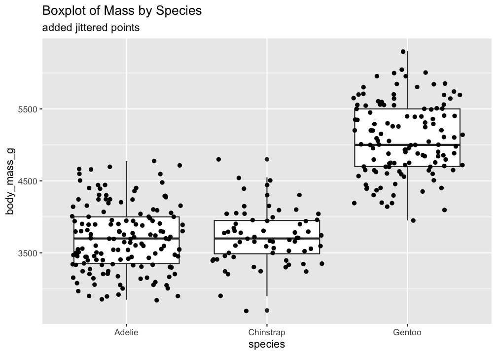

```r
## original flavor of jitter spans the whole space
penguins |> drop_na(body_mass_g) |> ggplot(aes(y = body_mass_g, x = species)) + geom_boxplot() + geom_jitter() + labs(title = "Boxplot of Mass by Species", subtitle = "added jittered points")
```

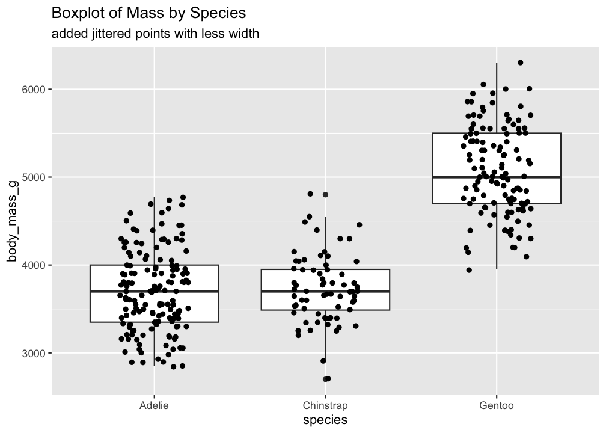

```r
## you can squash the points in with "width ="
## default is 40% of the resolution of the data
## (you can also change height, but that's not relevant here)
penguins |> drop_na(body_mass_g) |> ggplot(aes(y = body_mass_g, x = species)) + geom_boxplot() + geom_jitter(width = 0.2)  + labs(title = "Boxplot of Mass by Species", subtitle = "added jittered points with less width")
```

How to get the boxplots on top? The layers are plotted in the order you give them, so change the ordering to geom_point + geom_boxplot. (You might want to change the alpha on the boxplot to be able to see the plots under them)

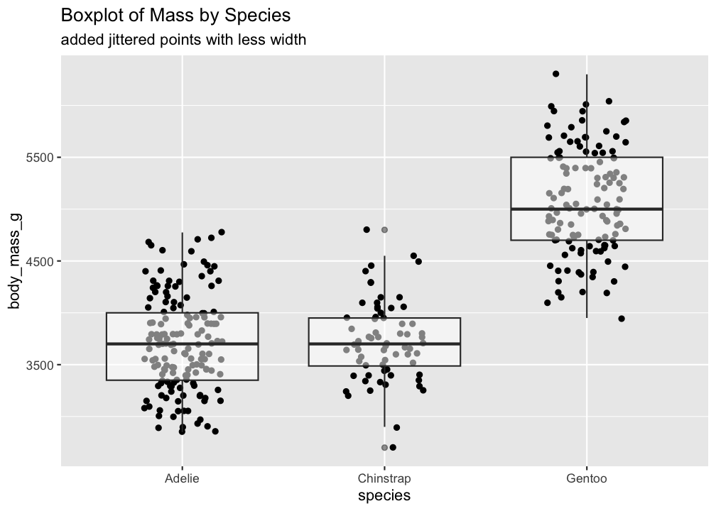

```r
penguins |>
  drop_na(body_mass_g) |>
  ggplot(aes(y = body_mass_g, x = species)) +
  geom_jitter(width = 0.2) +
  geom_boxplot(alpha = 0.5) +
  labs(title = "Boxplot of Mass by Species",
       subtitle = "added jittered points with less width")
```

Maybe let’s try replacing the boxplot with a `geom_violin()`?

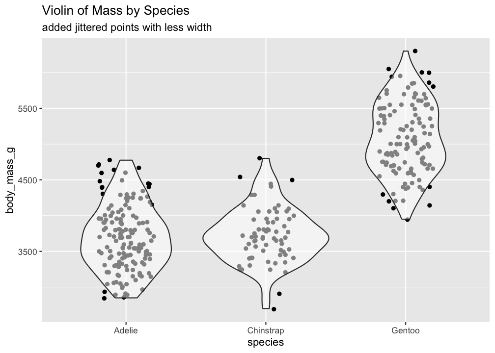

```r
penguins |>
  drop_na(body_mass_g) |>
  ggplot(aes(y = body_mass_g, x = species)) +
  geom_jitter(width = 0.2) +
  geom_violin(alpha = 0.5) +
  labs(title = "Violin of Mass by Species",
       subtitle = "added jittered points with less width")
```

## Presidental Elections Data

```r
# install.packages("pscl")
library(pscl) # loads in the package that has this data.
## You might need to install this...

# data for presidental elections
votedata <-  presidentialElections
glimpse(votedata)
```

```
## Rows: 1,097
## Columns: 4
## $ state   <chr> "Alabama", "Arizona", "Arkansas", "California", "Colorado", "C…
## $ demVote <dbl> 84.76, 67.03, 86.27, 58.41, 54.81, 47.40, 48.11, 74.49, 91.60,…
## $ year    <int> 1932, 1932, 1932, 1932, 1932, 1932, 1932, 1932, 1932, 1932, 19…
## $ south   <lgl> TRUE, FALSE, TRUE, FALSE, FALSE, FALSE, FALSE, TRUE, TRUE, FAL…
```

Let’s look at the democratic vote by state for 2000. We can’t use `geom_bar` for a bar chart, since we have the category in one variable and the “height” of the bar in another. We need `geom_col()`

Make a bar graph of the democratic vote by state in 2000.

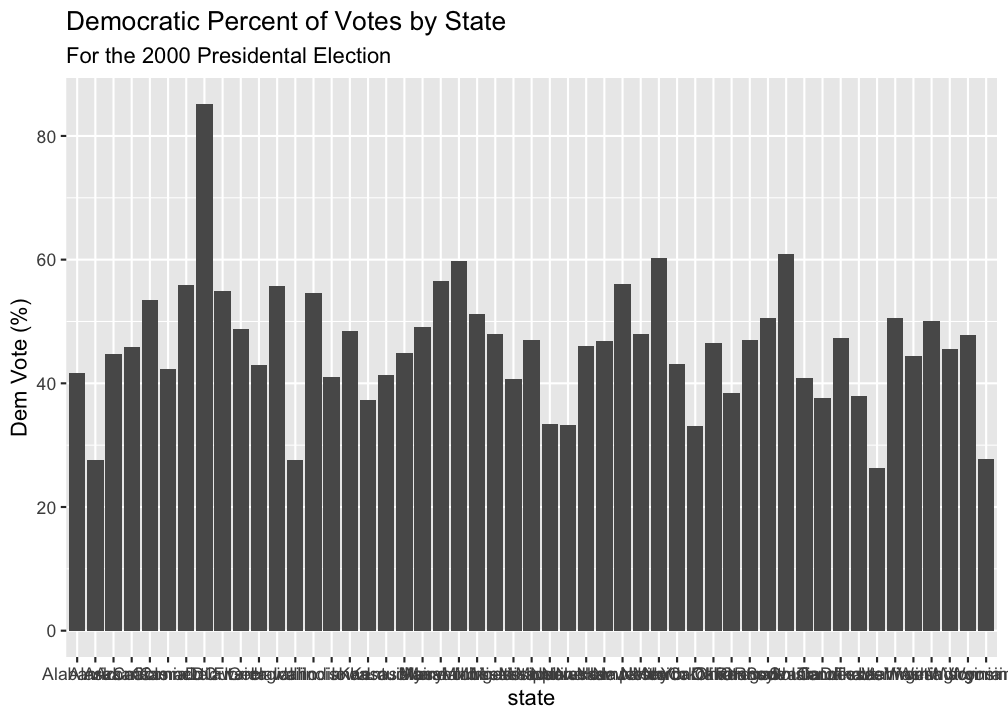

```r
votedata |>
  filter(year == 2000) |>
  ggplot(aes(x = state, y = demVote)) +
  geom_col() +
  labs(title = "Democratic Percent of Votes by State",
       subtitle = "For the 2000 Presidental Election",
       y = "Dem Vote (%)")
```

Well this looks awful. We have two options: swap the x and y or the more fun sounding… Coordinate flip!

Use `coord_flip()` on the previous graph to make it better.

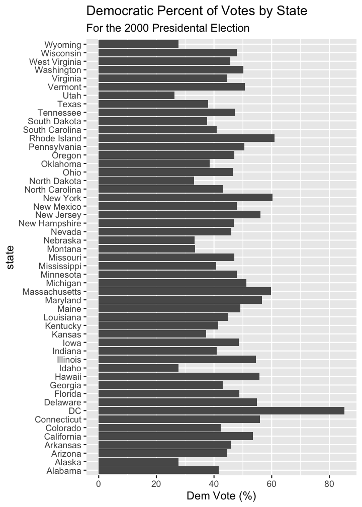

```r
votedata |>
  filter(year == 2000) |>
  ggplot(aes(x = state, y = demVote)) +
  geom_col() +
  coord_flip() +
  labs(title = "Democratic Percent of Votes by State",
       subtitle = "For the 2000 Presidental Election",
       y = "Dem Vote (%)")
```

I don’t love the squashed together coordinates, but it’s a display window issue.

So. This is a helpful graph, but it would be *more* helpful if it was ordered. Use `x = reorder(x_variable, y_variable)` in `aes()` to order the x variable by the y variable

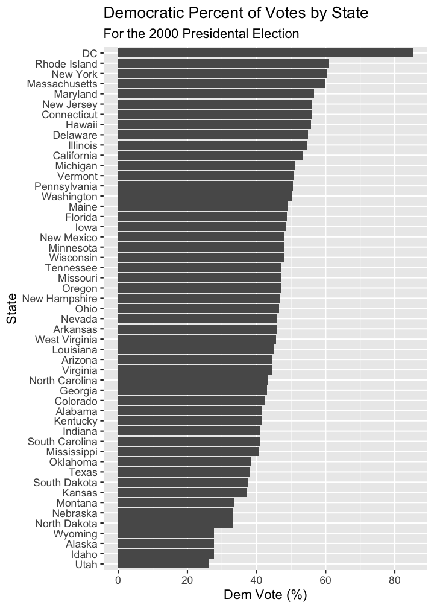

```r
# i added the code chunks post-publishing the template to fix this squashed graph too

votedata |>
  filter(year == 2000) |>
  ggplot(aes(x = reorder(state, demVote), y = demVote)) +
  geom_col() +
  coord_flip() +
  labs(title = "Democratic Percent of Votes by State",
       subtitle = "For the 2000 Presidental Election",
       y = "Dem Vote (%)",
       x = "State")
```

So, what if I want to see what the north and south states did different?

start with a facet_wrap using the `south` variable:

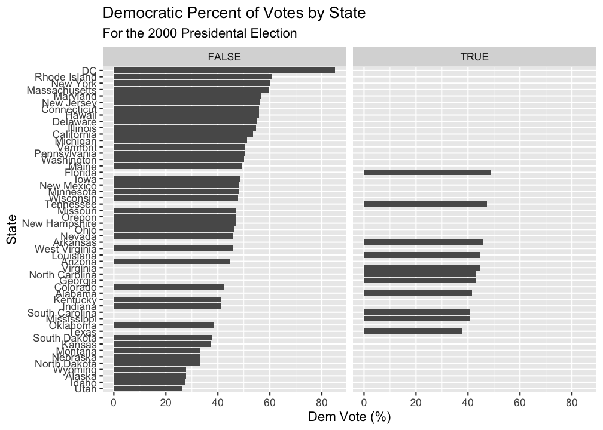

```r
votedata |>
  filter(year == 2000) |>
  ggplot(aes(x = reorder(state, demVote), y = demVote)) +
  geom_col() +
  coord_flip() +
  facet_wrap(~ south) +
  labs(title = "Democratic Percent of Votes by State",
       subtitle = "For the 2000 Presidental Election",
       y = "Dem Vote (%)",
       x = "State")
```

Okay, that’s not great. Lets *color* by south instead.

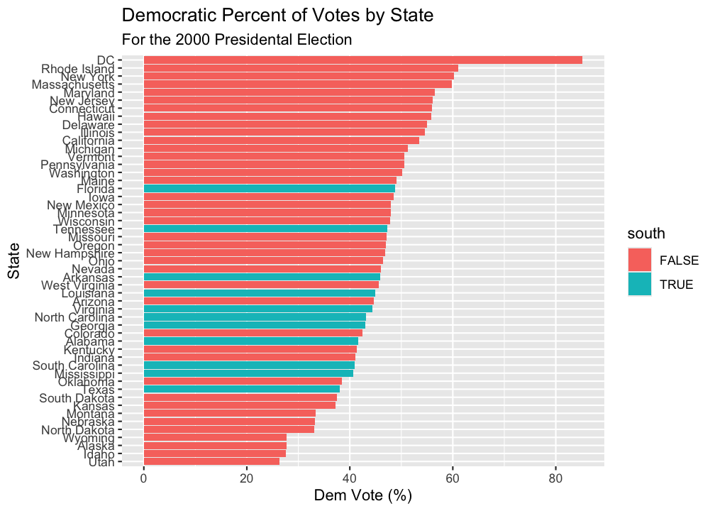

```r
## I use fill instead of color here cause it looks nicer
votedata |>
  filter(year == 2000) |>
  ggplot(aes(x = reorder(state, demVote), y = demVote, fill = south)) +
  geom_col() +
  coord_flip() +
  labs(title = "Democratic Percent of Votes by State",
       subtitle = "For the 2000 Presidental Election",
       y = "Dem Vote (%)",
       x = "State")
```

I’m a good data scientist, so I want my plot to have a name! and my axes to have lables! Use `labs` to add a title, subtitle, and x and y labels.

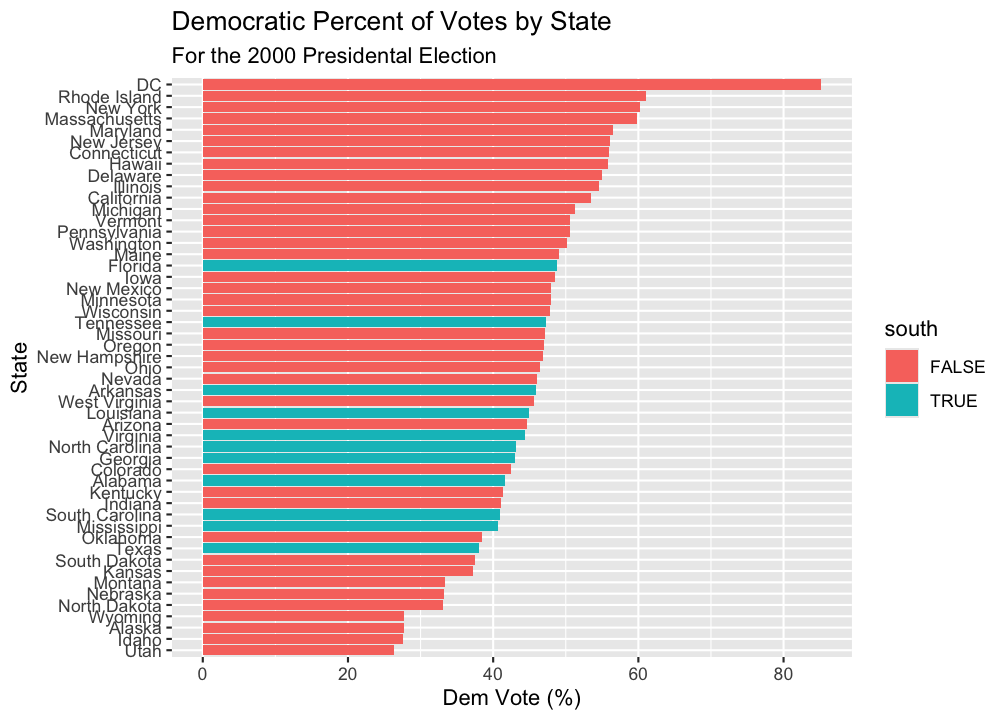

```r
## i've already been doing this...
votedata |>
  filter(year == 2000) |>
  ggplot(aes(x = reorder(state, demVote), y = demVote, fill = south)) +
  geom_col() +
  coord_flip() +
  labs(title = "Democratic Percent of Votes by State",
       subtitle = "For the 2000 Presidental Election",
       y = "Dem Vote (%)",
       x = "State")
```

You can move the legend with `theme(legend.position = "bottom")`

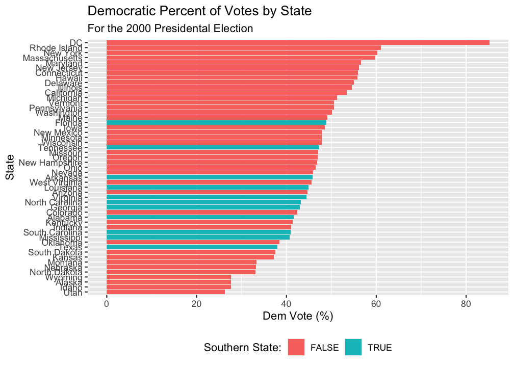

```r
votedata |>
  filter(year == 2000) |>
  ggplot(aes(x = reorder(state, demVote), y = demVote, fill = south)) +
  geom_col() +
  coord_flip() +
  labs(title = "Democratic Percent of Votes by State",
       subtitle = "For the 2000 Presidental Election",
       y = "Dem Vote (%)",
       x = "State",
       fill = "Southern State:") +
  theme(legend.position = "bottom")
```

What else could we facet by? years! Let’s filter to year in 2008 and 2016, then facet by years.

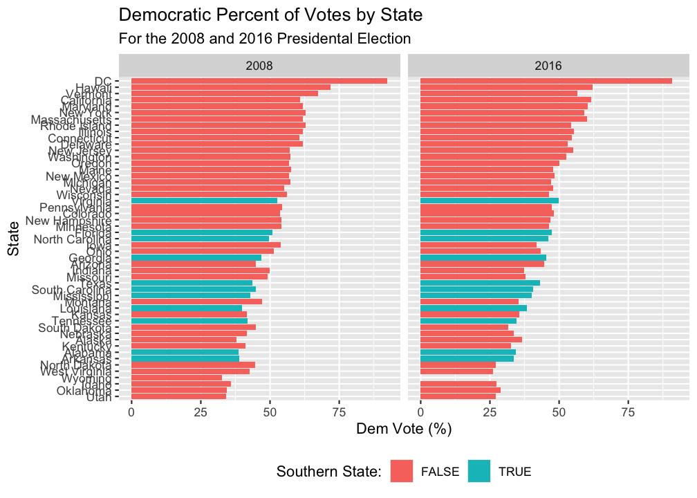

```r
votedata |>
  filter(year == 2008 | year == 2016) |>
    # this could also be year %in% c(2008, 2016)
  ggplot(aes(x = reorder(state, demVote), y = demVote, fill = south)) +
  geom_col() +
  coord_flip() +
  facet_wrap(~ year) +
  labs(title = "Democratic Percent of Votes by State",
       subtitle = "For the 2008 and 2016 Presidental Election",
       y = "Dem Vote (%)",
       x = "State",
       fill = "Southern State:") +
  theme(legend.position = "bottom")
```

```r
## this reorder is weird because it's reordering on overall total, since the axes need to match.
```

We need to know who won! We could add a vertical line at 50 for who got more, to indicate the majority of votes. Adding the layer `geom_hline()` adds a horizontal line. (What do you guess `geom_vline()` would do?)

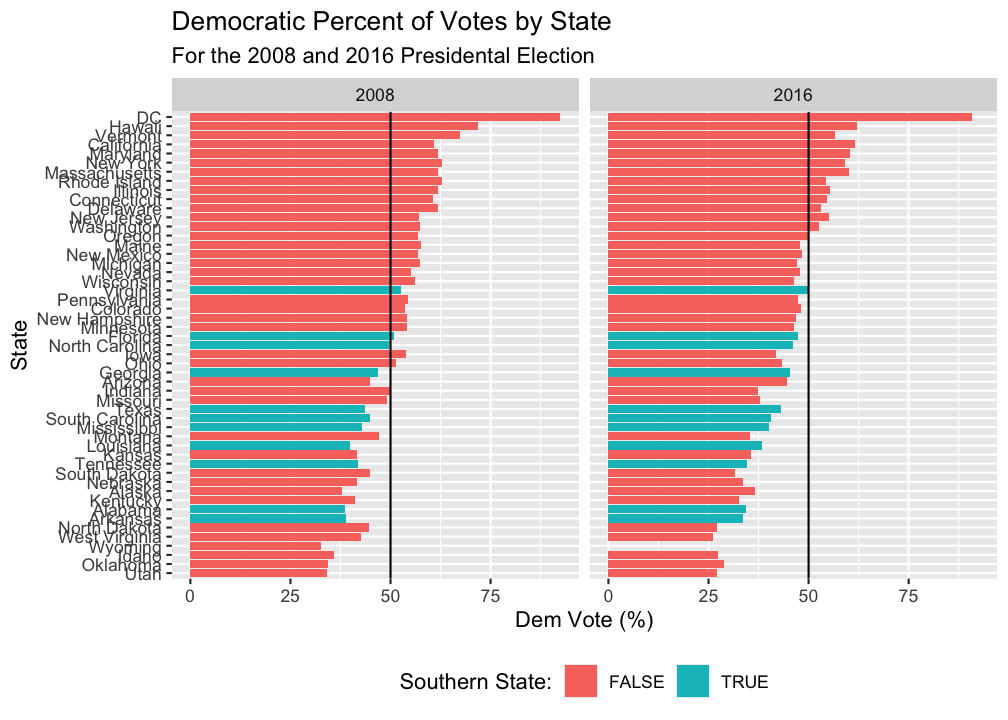

```r
votedata |>
  filter(year == 2008 | year == 2016) |>
    # this could also be year %in% c(2008, 2016)
  ggplot(aes(x = reorder(state, demVote), y = demVote, fill = south)) +
  geom_col() +
  geom_hline(yintercept = 50) +
    ## NOTE: this is weird because of the coordinate flip
  coord_flip() +
  facet_wrap(~ year) +
  labs(title = "Democratic Percent of Votes by State",
       subtitle = "For the 2008 and 2016 Presidental Election",
       y = "Dem Vote (%)",
       x = "State",
       fill = "Southern State:") +
  theme(legend.position = "bottom")
```